# Segregation and the Racial Wealth Gap in St. Louis, Missouri

Author

Matt Miller

[figure not shown]

#### Fall 2023

# Executive Summary

Given data from the United States Census Bureau, it’s clear that the city of St. Louis, Missouri hosts much segregation between the Black and White populations (Figure 1). While it’s possible to see where segregation exists in the city within the figure, it’s not possible to understand the negative economic impacts of segregation on the economic livelihoods of its Black citizens, the citizens that have historically suffered under segregation. Therefore, the analysis outlined in this document explores the relationship between segregation and the White/Black wealth gap, a measure that captures the difference in wealth between the White and Black populations. It also explores the impact of other variables of interest on the wealth gap like homeownership, education attainment, health insurance, and family stability.

Ultimately, the investigation into these variables concluded that education attainment, homeownership, and family stability have a statistically significant relationship with the wealth gap of St. Louis. It’s notable that segregation does not have a statistically significant relationship with the wealth gap.

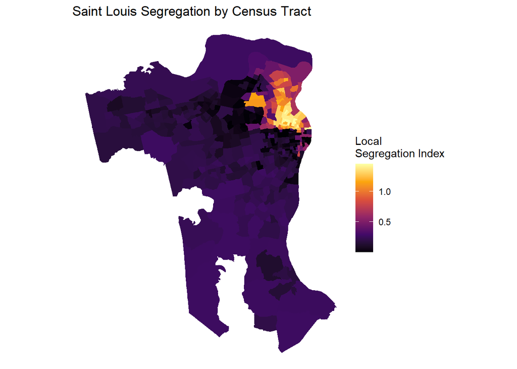

Figure 1: Map of Segregation in Saint Louis, Missouri. Higher values indicate higher levels of segregation. Map geometry collected using the Tigris package (Walker 2023) while segregation data was collected using the TidyCensus package (Walker and Herman 2023). Calculations for segregation were computed using the Segregation package (Elbers 2021).

# Topic and Research Question

## Research Question

The research question associated with the analysis asks if increasing levels of segregation result in increasing levels of the wealth gap in St. Louis. Addressing the research question is important as it provides valuable context of the St. Louis area’s main drivers of the wealth gap, thus enabling policymakers to formulate policies that can help promote economic opportunity for the Black population, a population that generally earns less income relative to its White counterpart.

In assessing the research question it’s possible to understand the statistically significant drivers of the wealth gap from the chosen variables of interest. Furthermore, it’s possible to understand if the legacy of segregation in St. Louis has a meaningful relationship with the wealth gap.

## Background Information

To understand the research question more thoroughly, it’s necessary to provide background on segregation and the wealth gap in St. Louis. In terms of segregation, the city of Saint Louis, is home to high levels of segregation between Black and White populations due to a history of racial housing covenants (Cooperman 2014). The racial housing covenants, initially created in 1916, “prevented anyone from buying a home in a neighborhood more than 75% occupied by another race (Cooperman 2014)]. When this specific practice was made illegal by the Buchanan v. Warley decision in the Supreme Court,”St. Louisans reverted to a different variety of housing covenant where every family on a block or in a subdivision had to sign a legal document promising to never sell to an African American” (Cooperman 2014). While the racial housing covenants requiring owners to never sell to African Americans were made illegal in 1948 following the Shelley v. Kraemer ruling at the Supreme Court, the legacy of racial housing covenants are still visible in the city today (Cooperman 2014)].

In addition to housing, division among the Black and White populations is also palpable given the respective wealth of each population. From a census tract perspective, the White population of Saint Louis has 1.72 times the wealth of the Black population (see wealth_gap mean of Figure Figure 3) . The wealth gap between the populations leaves the Black population at a disadvantage relative to the White population across multiple facets that include but are not limited to education, wealth appreciation, inheritance, etc.

Overall, there are clear divisions between the Black and White populations in terms of where residents live and how much wealth they have in the city of St. Louis. The subsequent analysis will attempt to understand if the two divisions are related.

# Key Concepts and Variables

Key concepts driving the investigation into the wealth gap are numerous. The key concepts provided below are from the perspective of the Black population. One key concept, home ownership, illustrates the idea that owning a home provides the homeowner with the ability to accrue wealth through appreciation and equity. The wealth accrued to the homeowner is then theoretically available to the next of kin after the homeowner’s death, thus increasing the total amount of wealth accrued to family members. Next, having health insurance implies that one can obtain needed health services, thus promoting economic productivity. Therefore, it’s expected that residents with health insurance will have higher levels of economic productivity and income, thus increasing the amount of wealth accrued to them. Family stability, defined as a family with two parents for this study, is expected to affect the accruement of wealth as stable families are in a better position to combine financial resources between partners. Education confers additional skills, and additional skills are largely associated with higher earning potential and wealth. Therefore, it’s expected that additional education will decrease the wealth gap. Segregation is expected to have a negative impact on wealth accumulation as segregated communities often host more poverty and diminished public services, thus negatively affecting future earnings prospects for residents.

The variables outlined in Table 1 below were computed using variables from the 2019 Five Year American Community Survey (ACS) from the United States Census Bureau . The computed variables align closely to the key concepts above. More information on how the variables outlined below were computed using information from the 2019 ACS can be found in Table A and Note A of the Appendix.

**Table 1**

Computed Variables used in Analysis

Variable

Description

```
wealth_gap
```

Median White Income divided by the Median Black Income

```
black_bachelors_prop
```

Proportion of Black population with a bachelor’s degree

```
black_health_insurance_
coverage_prop
```

Proportion of Black population with health insurance

```
black_owner_prop
```

Proportion of Black population that own homes

```
parents_in_household_prop
```

Proportion of households that have two caregivers for children present

```
segregation
```

Local segregation index

```
white_owner_prop
```

Proportion of White population that own homes

```
white_bachelors_prop
```

Proportion of White Population with a bachelor’s degree

```
white_health_insurance_
coverage_prop
```

Proportion of White population with health insurance

Finally, it’s worth noting that because the data in the variables come from a survey, the data are estimates of the population of St. Louis. Furthermore, the data was provided by respondents that may or may not have provided truthful answers. As a result of population estimation and survey response, it’s possible that the data is biased.

## Potential Limitations of Variables

The wealth gap for the study is computed as the White Median Income divided by the Black Median Income. While Median Income represents earnings, it does not represent total assets. As a result, it’s possible that the wealth gap measured in total assets between the White and Black populations is different relative to the Median White and Black Income computation. Next, Segregation is a calculation derived from via the ‘Local Segregation Index’ methodology. This approach uses multi-group segregation indices, which enables researchers to measure segregation among multiple groups like census tracts. While useful, the Local Segregation Index relies on a specific formulaic interpretation of segregation (see the segregation package Elbers (2021)) . It’s possible that other formulaic interpretations are more accurate for the purpose of this study. Finally, the Family Stability variable is captured in the data as the proportion of families with two parents in the same household. Overall, the relationship between the two parents is not given in the data. As a result, it’s possible that different types of relationships between the two parents have better predictive capacity of the wealth gap in St. Louis.

# Hypothesis and Theoretical Rationale

The analysis is based around the bivariate hypothesis that as segregation increases, the wealth gap increases. The rationale behind the hypothesis rests upon the idea that the distribution of wealth is rooted within a racist foundation that found the Black population restricted from buying property in wealthier neighborhoods, thus making it much more difficult for their communities to accrue wealth over time. For example, if a Black person had the funds to procure a house in a wealthy neighborhood while the racist housing covenants were in place, they were unable to legally do so. Instead, they were forced to buy a home in an area reserved for the black population where the public services were worse, and the housing prices were lower. Low housing prices coupled with poor public services led to a lack of appreciation in homes, meaning that intergenerational wealth was not accrued and passed down at the same rate as for White households. Furthermore, the poor public services meant that education was worse, leading to worse economic outcomes and lower rates home ownership on average for residents. The lack of high quality police, fire, and medical services meant that people were in danger more often and as a result, more stressed. This created a cycle of desperation and poverty that was very difficult to escape, even legally speaking. On the other hand, White residents procuring property at the time of the racist housing covenants had the ability to choose homes from mostly affluent areas with good public services and higher home values. As a result, the homes appreciated more, thus enabling higher transfers of intergenerational wealth. Better public services in these areas meant that education could be obtained publicly while police, fire, and medical services helped keep the population stress free. Overall, the cycle of poverty did not occur in these communities. Once this process started in the White and Black communities, it progressed, thus trapping many Black residents in a cycle of poverty while sparing many of the White residents. The areas that are predominantly White have a higher accumulation of wealth and prosperity while the Black communities have lower accumulations of wealth and prosperity. Therefore, I theorize that high rates of segregation increase the wealth gap between the White and Black populations.

# Methods and Data Sources

As previously mentioned, the data for the analysis originates from the 2019 Five Year ACS. Data from the Five Year ACS is collected over 60 months and has the largest sample size of any ACS survey, meaning that the results more closely resemble the population (Bureau 2022). Furthermore, the survey includes “estimates from over 40 topics for communities across the nation that include language, education, commuting, employment, mortgage status, rent, income, poverty and health insurance (Bureau 2022). The data from the ACS was procured using the tidycensus (Walker and Herman 2023) package in R. The package utilizes an Application Programming Interface (API) to connect users directly to the data at the Census Bureau.

To test the hypothesis that increasing levels of segregation leads to an increasing wealth gap, a multiple linear regression modeling technique was employed.

# Findings

While multiple linear regression is a useful tool in understanding statistical significance and the degree and direction of variables, it’s made more useful if the dataset is thoroughly analyzed from a descriptive statistic and a univariate perspective. The descriptive statistics shown in Figure 2 are associated with the constructed variables that align to the key concepts outlined in the previous section. Please take note of the 207 missing values under the wealth_gap variable. The large number of missing values relative to the total number of observations led to an exploratory data analysis into the missing data to better understand if Multiple Imputation by Chained Equations (MICE) could adequately impute the missing data. While the scatterplot shown in Appendix Figure 8 MICE appear appropriate, the density plot shown in Appendix Figure 9 indicates that the distribution of imputed values for Median Black and White Income, the two variables that constitute the Wealth Gap, vary drastically from their actual distributions. Therefore, the large respective number of observations were removed from the data as imputation did not appear appropriate for the study. The updated descriptive statistics after missing values were removed are shown in Figure 3.

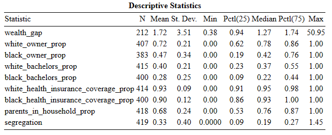

Figure 2: Summary Statistics for Saint Louis Dataset. Data Originates from the 2019 ACS via TIdycensus Walker and Herman (2023). Graphic generated with Stargazer Hlavac (2022) .

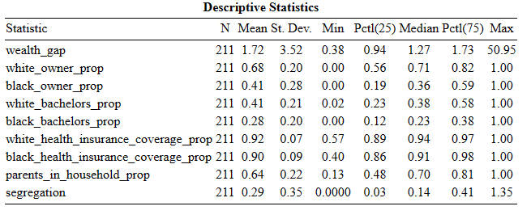

Figure 3: Summary Statistics Excluding Missing Values. Data Originates from the 2019 ACS via TIdycensus Walker and Herman (2023). Graphic generated with Stargazer Hlavac (2022) .

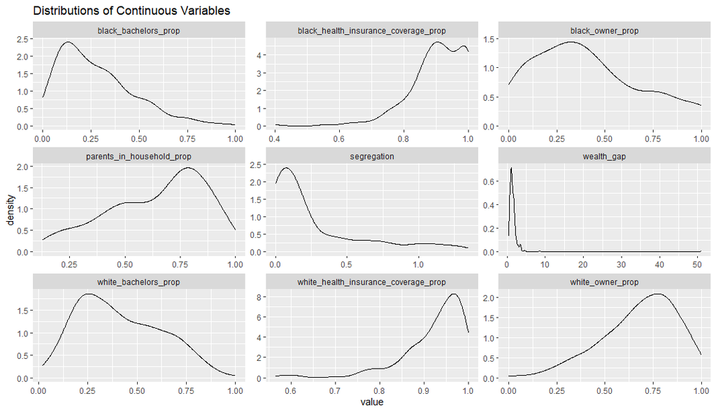

Figure 4: Univariate Distributions of Variables. Data Originates from the 2019 ACS via TIdycensus Walker and Herman (2023) . Graphic Generated with Tidyverse Wickham et al. (2019) .

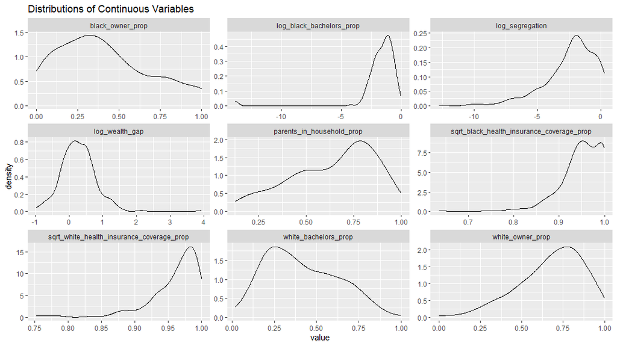

Figure 5: Univariate Distributions After Transformations. Data Originates from the 2019 ACS via TIdycensus Walker and Herman (2023) . Graphic Generated with Tidyverse Wickham et al. (2019) .

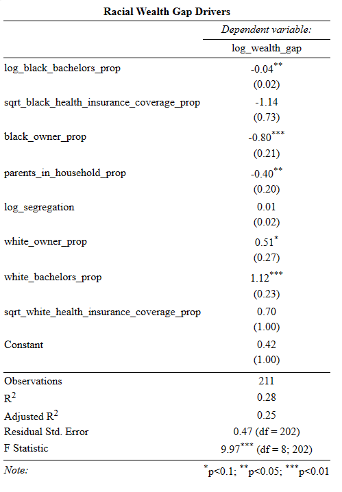

Figure 6: Regression Model with All Variables. Graphic Generated with Stargazer Hlavac (2022)

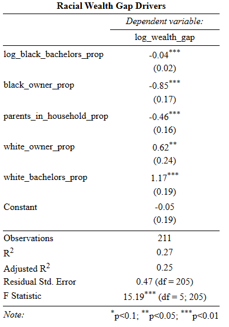

Figure 7: Regression Model with Statistically Significant Variables. Graphic Generated with Stargazer Hlavac (2022)

# Discussion

Overall, the hypothesis that increasing levels of segregation in associated with increasing levels of wealth gap in St. Louis was partially disconfirmed through the analysis as segregation was not statistically significant in its relationship to the wealth gap for the subset of census tracts in the model. That said, it’s possible that including the missing census tract values might change the conclusion. While it was surprising that segregation did not have a statistically significant relationship with the wealth gap for the available data, it was very surprising how different the coefficients of the regression output were for Black bachelor’s attainment and White bachelor’s attainment. Clearly, there are other variables at work that were not captured in the study that contribute to the degree to which income is earned through bachelor’s degrees from the Black and White populations. Based on the results, I’m interested in exploring more on the differences in income between Blacks and Whites with bachelor’s degrees. With more time and resources, I would like to test the hypothesis that being Black with a bachelor’s degree in St. Louis confers less additional income relative to being White with a bachelor’s degree. To test this hypothesis, I would execute a similar approach to this study; namely, I would utilize a multiple linear regression model with median income as the dependent variable for Blacks and Whites respectively with the bachelor’s degree prop as the independent variable of interest. Overall, there is much more to explore in St. Louis related to race, income, and economic mobility.

# R Packages Used in this Analysis

The analysis executed in this document utilized the following R packages: Tidyverse Wickham et al. (2019), Tidycensus Walker and Herman (2023), Tigris Walker (2023), Segregation Elbers (2021), Sf Pebesma (2018), VIM Kowarik and Templ (2016), Mice van Buuren and Groothuis-Oudshoorn (2011), Scales Wickham and Seidel (2022), Car Fox and Weisberg (2019), Stargazer Hlavac (2022), and Sandwich Zeileis (2004).

## References

Bureau, United States Census. 2022. *American Community Survey 2017-2021 5-Year Data Release*. https://www.census.gov/newsroom/press-kits/2022/acs-5-year.html.

Cooperman, Jeannette. 2014. *The Story of Segregation in St. Louis*. https://www.stlmag.com/news/the-color-line-race-in-st.-louis/.

Elbers, Benjamin. 2021. “A Method for Studying Differences in Segregation Across Time and Space.” *Sociological Methods & Research* 52 (1): 5–42. https://doi.org/10.1177/0049124121986204.

Fox, John, and Sanford Weisberg. 2019. *An R Companion to Applied Regression*. Third. Thousand Oaks CA: Sage. https://socialsciences.mcmaster.ca/jfox/Books/Companion/.

Hlavac, Marek. 2022. *Stargazer: Well-Formatted Regression and Summary Statistics Tables*. Bratislava, Slovakia: Social Policy Institute. https://CRAN.R-project.org/package=stargazer.

Kowarik, Alexander, and Matthias Templ. 2016. “Imputation with the R Package VIM.” *Journal of Statistical Software* 74 (7): 1–16. https://doi.org/10.18637/jss.v074.i07.

Pebesma, Edzer. 2018. “Simple Features for R: Standardized Support for Spatial Vector Data.” *The R Journal* 10 (1): 439–46. https://doi.org/10.32614/RJ-2018-009.

van Buuren, Stef, and Karin Groothuis-Oudshoorn. 2011. “mice: Multivariate Imputation by Chained Equations in r.” *Journal of Statistical Software* 45 (3): 1–67. https://doi.org/10.18637/jss.v045.i03.

Walker, Kyle. 2023. *Tigris: Load Census TIGER/Line Shapefiles*. https://CRAN.R-project.org/package=tigris.

Walker, Kyle, and Matt Herman. 2023. *Tidycensus: Load US Census Boundary and Attribute Data as ’Tidyverse’ and ’Sf’-Ready Data Frames*. https://CRAN.R-project.org/package=tidycensus.

Wickham, Hadley, Mara Averick, Jennifer Bryan, Winston Chang, Lucy D’Agostino McGowan, Romain François, Garrett Grolemund, et al. 2019. “Welcome to the tidyverse.” *Journal of Open Source Software* 4 (43): 1686. https://doi.org/10.21105/joss.01686.

Wickham, Hadley, and Dana Seidel. 2022. *Scales: Scale Functions for Visualization*. https://CRAN.R-project.org/package=scales.

Zeileis, Achim. 2004. “Econometric Computing with HC and HAC Covariance Matrix Estimators.” *Journal of Statistical Software* 11 (10): 1–17. https://doi.org/10.18637/jss.v011.i10.

### Table A

Variable

Description

```
medinc_blackE
```

Estimated median black income

```
medinc_whiteE
```

Estimated median white income

```
whiteE
```

Estimate of total population that is white

```
blackE
```

Estimate of total population that is black

```
white_owner_occupiedE
```

Estimate of number of home units owned by whites

```
white_occupied_housingE
```

Estimate of total number of units occupied by whites

```
black_owner_occupiedE
```

Estimate of home units owned by blacks

```
black_occupied_housingE
```

Estimate of total number of units occupied by blacks

```
white_male_bachelorsE
```

Estimate of total number of white males with a bachelor’s degree

```
white_female_bachelorsE
```

Estimate of total number of white females with a bachelor’s degree

```
white_estimate_25_and_
olderE
```

Estimate of total number of whites age 25 and older

```
black_male_bachelorsE
```

Estimate of total number of black males with a bachelor’s degree

```
black_female_bachelorsE
```

Estimate of total number of black females with a bachelor’s degree

```
black_estimate_25_and_
olderE
```

Estimate of total number of blacks age 25 and older

```
white_under_19_health_
insuranceE
```

Estimate of total number of whites under 19 with health insurance

```
white_19_to_64_health_
insuranceE
```

Estimate of total number of whites age 19-64 with health insurance

```
white_65_and_older_health_
insuranceE
```

Estimate of total number of whites age 65 and older with health insurance

```
white_noninstitutional
ized_popE
```

Estimate of total number of whites that are not instituitionalized

```
black_under_19_health_
insuranceE
```

Estimate of total number of blacks under 19 with health insurance

```
black_19_to_64_health_
insuranceE
```

Estimate of total number of blacks age 19-64 with health insurance

```
black_65_and_older_health_
insuranceE
```

Estimate of total number of blacks age 65 and older with health insurance

```
black_noninstituitional
ized_popE
```

Estimate of total number of blacks that are not institutionalized

```
married_household_w_
childrenE
```

Estimate of total number of households with a married couple that have children

```
cohabitating_household_w_
childrenE
```

Estimate of total number of households with a cohabitating couple that have children

```
toal_w_childrenE
```

Estimate of the total number of households with children

### Note A

The following calculations were made to determine the variables used in the regression analysis that align to the key concepts:

**white_owner_prop** = white_owner_occupiedE / white_occupied_housingE

**black_owner_prop** = black_owner_occupiedE / black_occupied_housingE

**white_bachelors_prop** = (white_male_bachelorsE + white_female_bachelorsE) / white_estimate_25_and_olderE

**black_bachelors_prop** = (black_male_bachelorsE + black_female_bachelorsE) / black_estimate_25_and_olderE

**black_health_insurance_coverage_prop** = (black_under_19_health_insuranceE + black_19_to_64_health_insuranceE + black_65_and_older_health_insuranceE) / black_noninstituitionalized_popE

**white_health_insurance_coverage_prop** = (white_under_19_health_insuranceE + white_19_to_64_health_insuranceE + white_65_and_older_health_insuranceE) / white_noninstitutionalized_popE

**parents_in_household_prop** = (married_household_w_childrenE + cohabitating_household_w_childrenE) / toal_w_childrenE

**wealth_gap** = medinc_whiteE / medinc_blackE

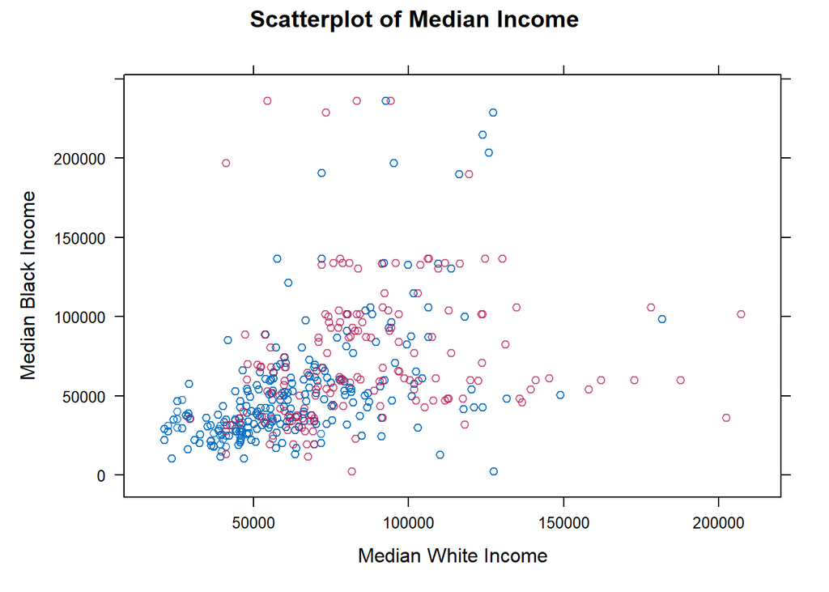

Figure 8: Scatterplot of Actual Median Income Values in Blue and Imputed Median Black Income Values in Red. Imputed values computed using MICE van Buuren and Groothuis-Oudshoorn (2011). Graphic generated with VIM Kowarik and Templ (2016)

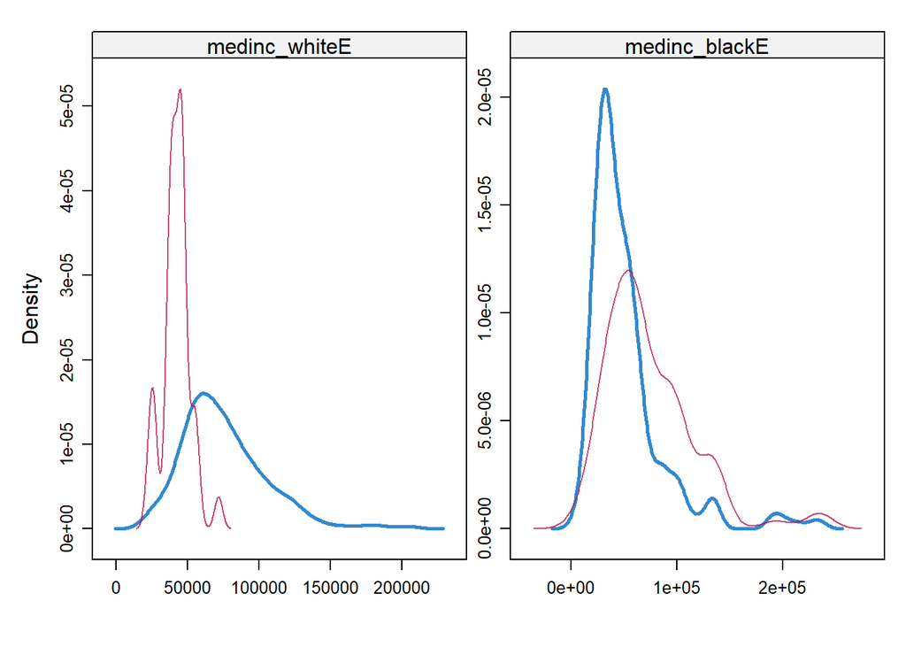

Figure 9: Density Plot of Actual Median Income Values in Blue and Imputed Median Income Values in Red for Median Black and White Income. Imputed values computed using MICE van Buuren and Groothuis-Oudshoorn (2011). Graphic generated with VIM Kowarik and Templ (2016)

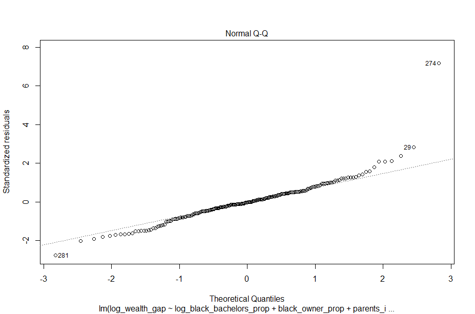

Figure 10: QQ Plot Indicates an Approximate Normality. Notable Differences are on the Tail Ends

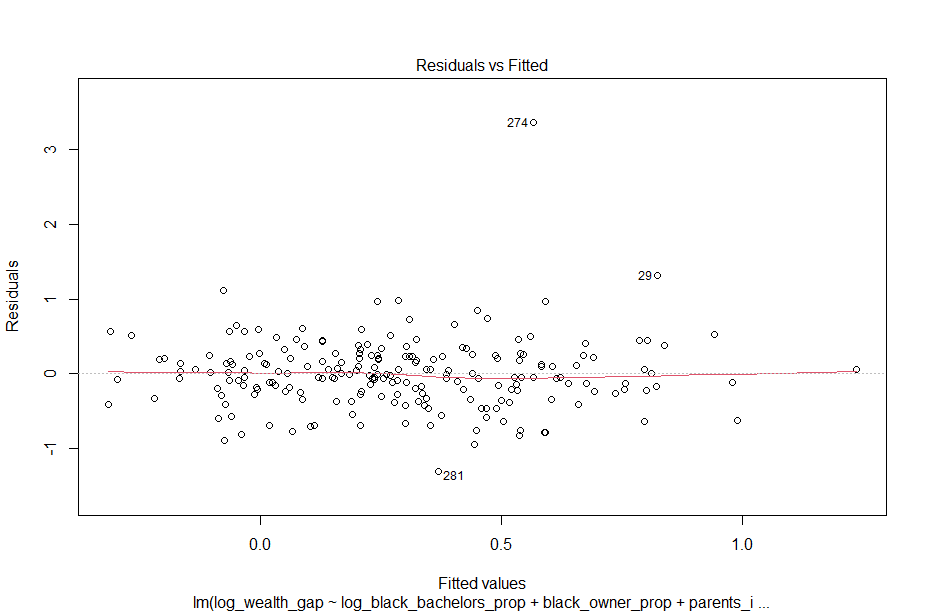

Figure 11: Residuals vs. Fitted Plot Indicates Homoscedasticity

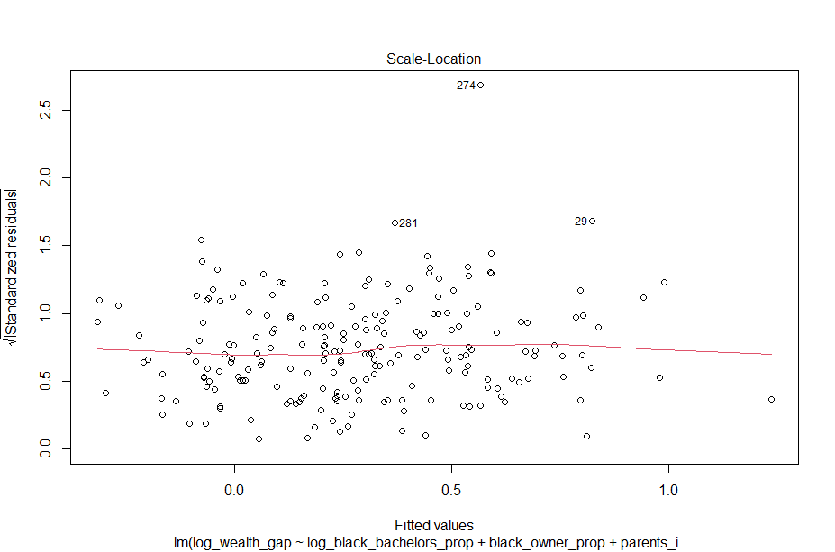

Figure 12: Scale Location Graph Indicates Approximate Homoscedasticity

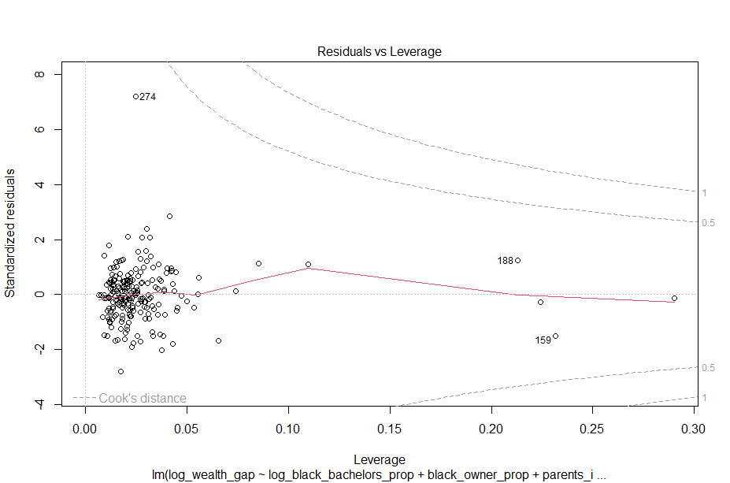

Figure 13: Residuals vs. Leverage Plot Indicates No Outliers as Measured by Cook’s Distance